# STA207 Hw7 - Eric Kalosa-Kenyon

```r
library("plyr")
library("lmtest")
library("gdata")            # reads .xlsx
library("car")              # calculates variance inflation
library("MASS")             # ridge regression
```

# 14.39

## 14.39.a

```r
df = read.csv("CH14PR39.csv", header=F)
names(df) = c("Falls", "Intervention", "Gender", "Balance", "Strength")
fit = with(df,
        glm(Falls~Intervention+Gender+Balance+Strength, family = poisson()
    ))
fit.s = summary(fit)
fit.e = coef(fit.s)[,2]
```

The model is $Y=e^{b_0+b_1*X_1+b_2*X_2+b_3*X_3+b_4*X_4}$ where $b_0=0.7089394\pm 0.3400593$, $b_1=-0.9609231\pm 0.1346007$, $b_2=-0.1138156\pm 0.1236$, $b_3=0.0117326\pm 0.0030403$, and $b_4=0.0018787\pm 0.0044384$.

## 14.39.b

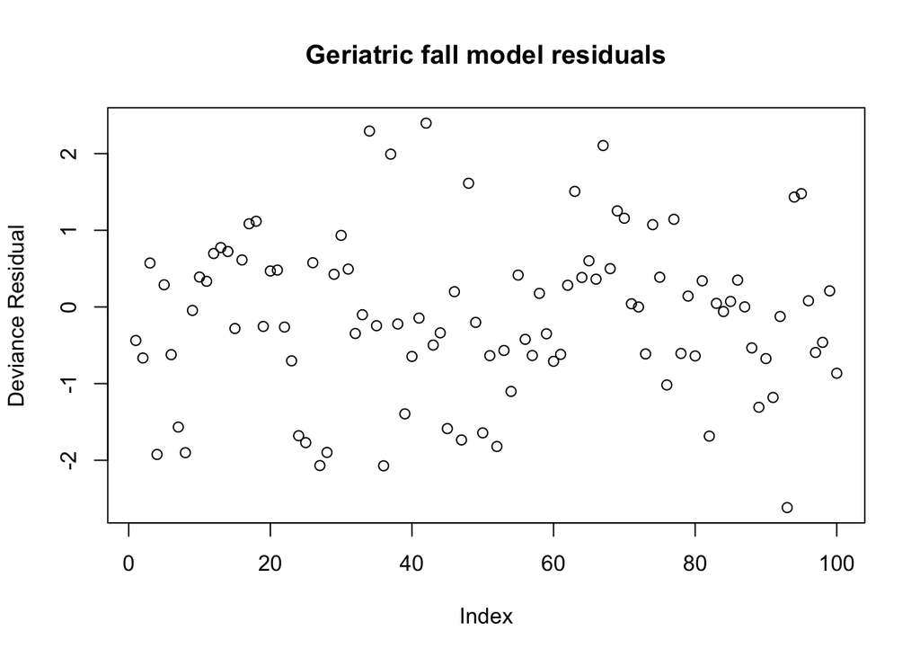

```r
fit.dr = residuals(fit, "deviance")
plot(fit.dr, ylab="Deviance Residual", main="Geriatric fall model residuals")
```

There are a few outliers, but nothing totally egrigious. The lack of serious outliers is evidenced by the relative normality of the following histogram of the residuals:

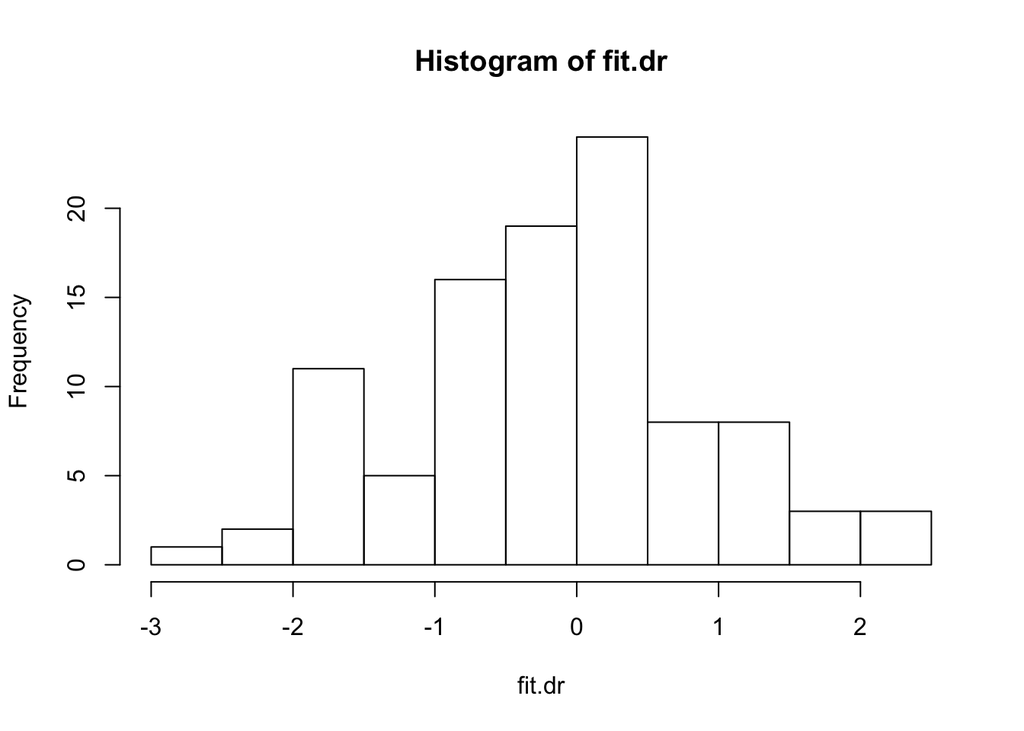

```r
hist(fit.dr)
```

## 14.39.c

```r
fit.red = with(df,
        glm(Falls~Intervention+Balance+Strength, family = poisson()
    ))
fit.aov = anova(fit, fit.red, test="Chi")
a = fit.aov["Pr(>Chi)"][2,]
```

The likelihood ratio test yields a p-value of $0.3567951>\alpha=0.05$ so we fail to reject the null hypothesis $H_0:b_2=0$ and conclude that there may not be a gender effect on on the number of falls in geriatric study participants.

## 14.39.d

```r
b1 = fit.red$coefficients[2]
fit.red.s = summary(fit.red)
fit.red.e = coef(fit.red.s)[,2]
s1 = fit.red.e[2]
m = 1.96*s1
```

The $95$% CI for $b_1$ is $[-1.2407768, -0.7193597]$. This interval does not contain zero so we reject the null hypothesis $H_0:b_1=0$ that intervention does not reduce accident rate.

# 1

## 1.a

```r
df = read.xls("apartment.xlsx", sheet = 1, header = TRUE)
names(df) = c("Price", "Age", "NumUnits", "LotSize", "Parking", "Area")
for (i in 1:dim(df)[2]){
    d = df[,i]
    mi = min(d)
    ma = max(d)
    df[,i] = (d-mi)/(ma-mi)
}
head(df)
```

```
##        Price        Age   NumUnits     LotSize Parking       Area
## 1 0.01262916 1.00000000 0.00000000 0.007580352     0.0 0.03367392
## 2 0.35017222 0.04166667 0.27586207 0.805821710     0.0 0.31177214
## 3 0.08955224 0.77777778 0.01724138 0.085081868     0.0 0.09819270
## 4 0.68541906 0.75000000 0.37931034 0.196482717     0.3 0.85431773
## 5 0.09873708 0.62500000 0.01724138 0.038811401     0.0 0.08459679
## 6 0.25373134 0.76388889 0.10344828 0.484899939     0.0 0.31619424
```

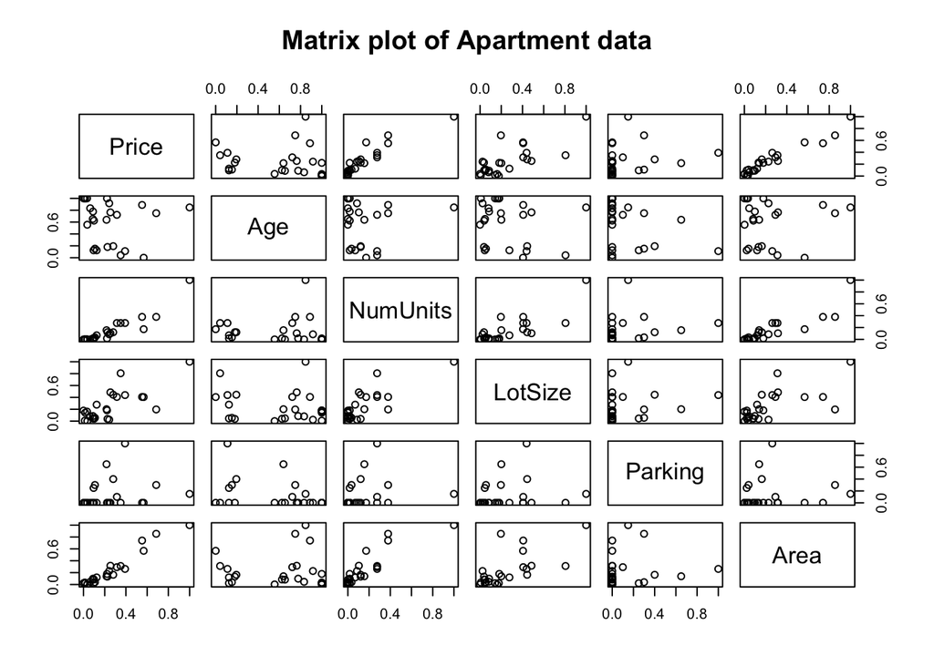

```r
plot(df, main="Matrix plot of Apartment data")
```

$X_2$ and $X_5$ appear correlated. $X_2$ and $X_3$ appear correlated, too. Hence, $X_3$ and $X_5$ are commensurately correlated. There is an apparent relationship between $X_4$ and $X_5$ but it doesn’t look linear.

## 1.b

```r
X = as.matrix(df[,2:6])
xtx = t(X)%*%X
eig = eigen(xtx)
```

The eigenvalues of the covariance matrix $X^TX$ are $\lambda=[15.5117827, 4.0195927, 1.4481796, 0.5543662, 0.1385244]$. The 2 leading values are quite large compared to the tailing three, so we know the majority of the variation in the data is described by the first 2 eigenvectors.

## 1.c

```r
fit = lm(Price~., data=df)
```

```r
summary(fit)
```

```
##
## Call:
## lm(formula = Price ~ ., data = df)
##
## Residuals:
##       Min        1Q    Median        3Q       Max
## -0.062380 -0.019770 -0.004844  0.017111  0.084157
##
## Coefficients:
##             Estimate Std. Error t value Pr(>|t|)
## (Intercept)  0.08401    0.02226   3.775  0.00128 **
## Age         -0.07068    0.02465  -2.867  0.00986 **
## NumUnits     0.27615    0.09924   2.783  0.01186 *
## LotSize      0.01773    0.05442   0.326  0.74807
## Parking      0.06199    0.03618   1.713  0.10295
## Area         0.65019    0.06109  10.643 1.91e-09 ***
## ---
## Signif. codes:  0 '***' 0.001 '**' 0.01 '*' 0.05 '.' 0.1 ' ' 1
##
## Residual standard error: 0.03811 on 19 degrees of freedom
## Multiple R-squared:  0.9805, Adjusted R-squared:  0.9754
## F-statistic: 191.3 on 5 and 19 DF,  p-value: 1.452e-15
```

## 1.d

```r
fit.vif = vif(fit)
fit.vif[1:5]
```

```
##      Age NumUnits  LotSize  Parking     Area
## 1.298654 7.657888 3.157590 1.316618 4.670186
```

None of the $VIF$ are larger than $10$, but some are close, so we consider the possibility of collinearity in this data.

## 1.e

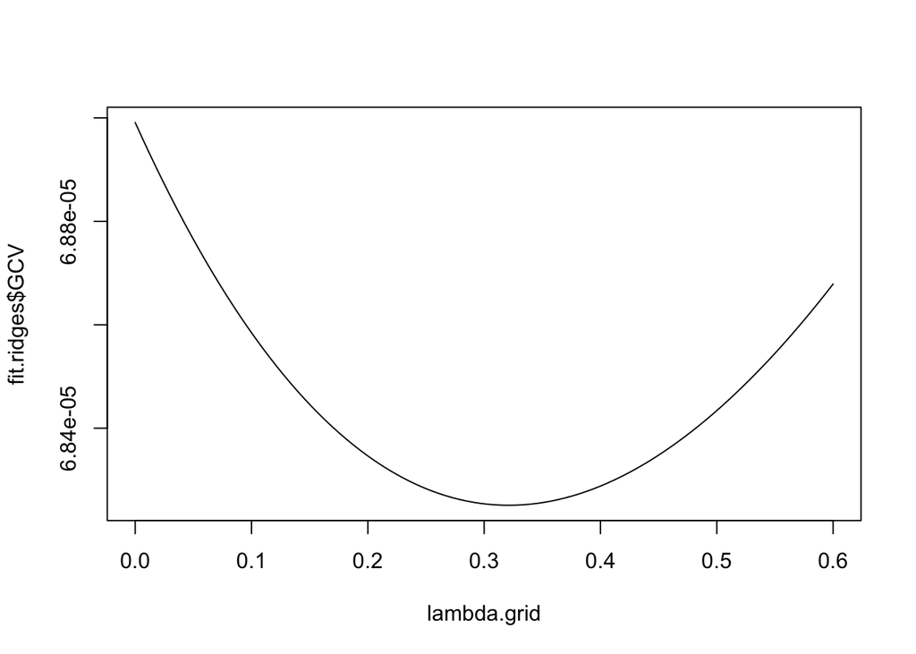

```r
lambda.grid = seq(0,0.6,len=100)
fit.ridges = lm.ridge(Price~1+., lambda = lambda.grid, data=df)
plot(lambda.grid, fit.ridges$GCV, type='l')
```

```r
wl = which(fit.ridges$GCV == min(fit.ridges$GCV))
lopt = lambda.grid[wl]
```

The penalty we find with cross validation is $\hat{\lambda}_{opt}=0.3212121$. Fitting the ridge regression with this penalty, we find:

```r
fit.ridge = lm.ridge(Price~1 + ., lambda = lopt, data=df)
fit.ridge
```

```
##                     Age    NumUnits     LotSize     Parking        Area
##  0.08485104 -0.06892480  0.29491069  0.02308903  0.05994786  0.62594862
```

```r
Y = as.matrix(df$Price)
XX = cbind(rep(1,25), X)
b = as.matrix(coef(fit.ridge))
res = Y-XX%*%b
sse = sum((res)^2)
mse = sse/25
sd = sqrt(mse)
```

And the standard error turns out to be $s=0.0333917$.

## 1.f

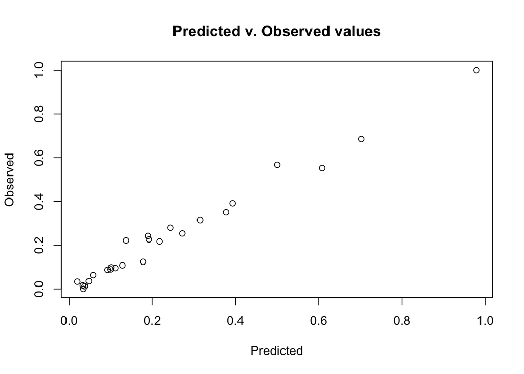

```r
plot(XX%*%b, df$Price, ylab="Observed", xlab="Predicted",
     main="Predicted v. Observed values")
```

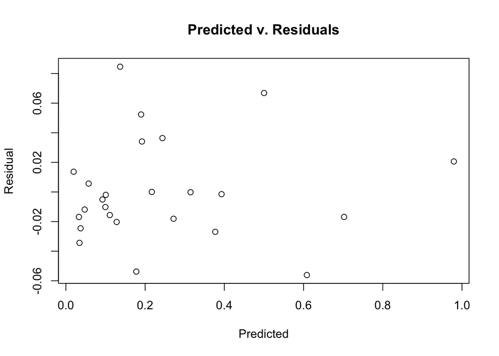

```r
plot(XX%*%b, res, ylab="Residual", xlab="Predicted",
     main="Predicted v. Residuals")
```

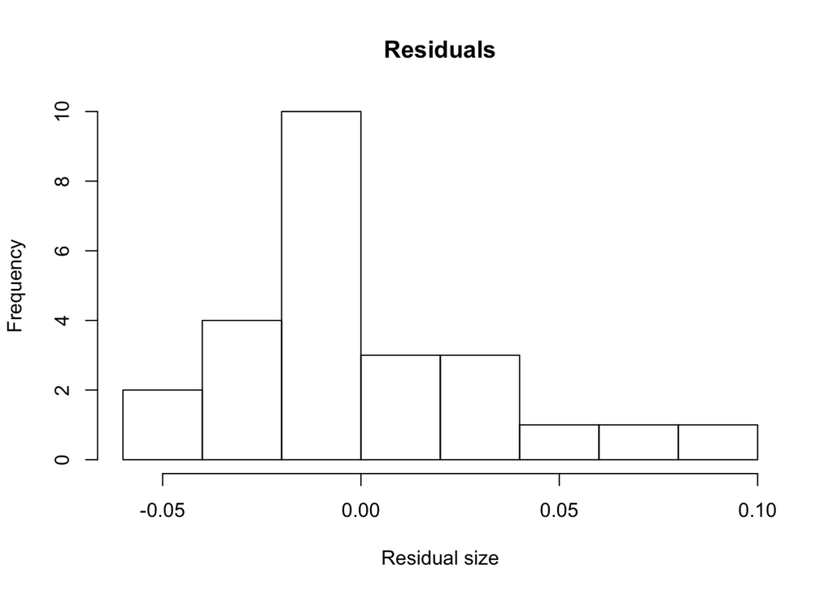

```r
hist(res, main="Residuals", xlab="Residual size")
```

The errors appear normally distributed and homoskedastic.

## 1.e

```r
vif.ridge =
    solve(t(X)%*%X+lopt*diag(5))%*%t(X)%*%X%*%solve(t(X)%*%X+lopt*diag(5))
diag(vif.ridge)
```

```
##       Age  NumUnits   LotSize   Parking      Area
## 0.1096639 0.5493504 0.5216514 0.4412842 0.4943364
```

```r
fit.vif[1:5]
```

```
##      Age NumUnits  LotSize  Parking     Area
## 1.298654 7.657888 3.157590 1.316618 4.670186
```

The variance inflation factors for ridge regression are much smaller than the non-ridge vif.